# Lezione - Dati e modelli

## Campioni casuali i.i.d.

Da qui avanti useremo prevalentemente campioni casuali semplici con ripetizione generalizzando lo schema a **popolazioni infinite** e definendo i cosiddetti **campioni i.i.d.** ossia con componenti **indipendenti e identicamente distribuite**.

> **Definizione**. Un **campione casuale i.i.d.** di dimensione $n$ da una popolazione con funzione di ripartizione $F$ è un $n$-pla di v.a. $Y = (Y_1, \dots, Y_n )$ indipendenti e identicamente distribuite tali che
> - $\Pr(Y_1 \le y_1 \cdots Y_n \le y_n) = \textstyle \prod_{i=1}^n F(y_i), \quad \text{per ogni } y_i \in \mathbb{R}^n$
> - $Y_i \sim F ,\; \text{per ogni $i = 1, \dots, n$}$.

> **Notazione** Useremo spesso la notazione $(Y_1, \dots, Y_n) \stackrel{iid}{\sim} F$.

### Illustrazione mediante simulazioni

- Un campione i.i.d. da una normale standard $N(0,1)$ di dimensione $n = 20$.

```r
y = rnorm(n = 20, mean = 0, sd = 1)
y
```

```
 [1]  1.49109 -1.92679 -0.09912 -0.81650 -0.99426  1.62833  0.71142 -0.55746
 [9] -0.74744 -0.91687  0.27462 -0.27303  0.43888 -1.80629 -0.06640  0.07198
[17]  1.10283 -0.54432 -0.65744 -0.69576
```

- Un campione i.i.d. da una $Bernoulli(0.5)$ di dimensione $n = 20$.

```r
y = rbinom(n = 20, size = 1, prob = 0.5)
y
```

```
 [1] 1 0 1 0 0 0 0 1 0 1 0 0 0 1 1 0 1 1 0 0
```

- Un campione i.i.d. da una $Poisson(\lambda = 10)$ di dimensione $n = 20$.

```r
y = rpois(n = 20, lambda = 10)
y
```

```
 [1]  9 15 17  9 14  9 11 11 19 11  6 17  5 12 16 11  9  6 10 10
```

- Un campione i.i.d. di dimensione 200, da una normale doppia con media $(0,0)$ e matrice di covarianza

$$\begin{pmatrix}
1 & -0.7\\
-0.7 & 1\\
\end{pmatrix}$$

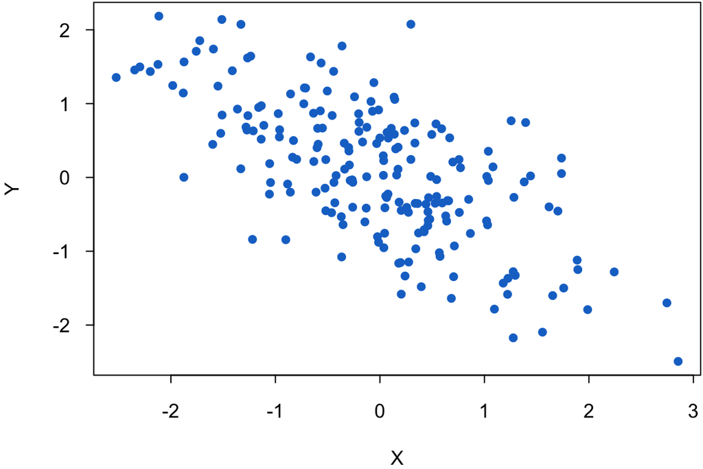

```r
require(mvtnorm)  # Carica il package che definisce
                  # la normale multivariata
m = c(0,0)
S = matrix(c(1, -0.7, -0.7, 1), 2, 2)
U = rmvnorm(n = 200, mean = m, sigma = S)
plot(U, pch = 20, cex = 1.3, col = 'dodgerblue3', xlab = 'X', ylab = 'Y')
```

## Modelli di popolazione

Ogni popolazione è dunque descritta da una variabile aleatoria $Y$ con una distribuzione $F(y)$.

Le popolazioni sono oggetti di studio della statistica

- **osservabili** solo parzialmente,
- con una **struttura in gran parte incognita**

È importante all’inizio dell’analisi definire cosa sappiamo e cosa non sappiamo di una popolazione. Questa definizione è chiamata **specificazione** della distribuzione. Possiamo avere una specificazione

- **parametrica** - se si sceglie una famiglia di distribuzione di tipo noto dipendente da un numero ridotto di parametri
- **non parametrica** - se si sceglie una famiglia di distribuzioni estremamente ampia che fa il minimo di assunzioni

### Distribuzioni univariate

Spesso il modello di popolazione si sceglie utilizzando una classe nota di distribuzioni di probabilità e cercando di rispettare la natura del fenomeno studiato. La tabella seguente riporta alcune famiglie univariate di uso comune, con i relativi **parametri**. Questi sono indicati genericamente con $\theta \in \Theta$ e possono essere multidimensionali; si veda la tabella seguente.

$$\begin{array}{lllcc}
\text{Distribuzione} & \text{Dati} & \mathcal{Y} & \theta & \Theta \\ \hline
\text{Bernoulli} & \text{binari} & 0,1 & \theta & (0,1) \\
\text{Binomiale} & \text{proporzioni}& 0, 1,\dots, n & n, \theta & (1,2,\dots) \times(0,1) \\
\text{Poisson} & \text{conteggi} & \mathbb{N} & \lambda & (0,\infty) \\
\text{Esponenziale} & \text{durate} & (0, \infty) & \lambda & (0,\infty) \\
\text{Normale} & \text{misure} & \mathbb{R} & \mu, \sigma^2 & \mathbb{R} \times(0,\infty) \\ \hline
\end{array}$$

### Distribuzioni multivariate

Quando una popolazione è multivariata essa viene descritta da un **vettore aleatorio** $U$. Per esempio se la popolazione riguarda due variabili $U = (X,Y)$ essa è definita da una distribuzione di probabilità bivariata. Due distribuzioni molto usate nelle applicazioni sono

- La **Bernoulli multivariata**
- La **normale multivariata**

Ne parleremo in dettaglio più avanti nel corso.

### Regressione

In molti casi

- una variabile $Y$ svolge un ruolo di variabile **dipendente**
- un altra varibile $X$ ha il ruolo di variable **esplicativa**. In tal caso si studiano le popolazioni definite dalle distribuzioni **condizionate** di $Y\mid X = x$.

> $X$ in generale può essere anche un **vettore** di variabili esplicative $X = (X_1, X_2, \dots, X_k)$.

## Modelli statistici

In generale, supporremo che i dati osservati, le **osservazioni**, abbiano la forma

$$(x_1, y_1) , \dots, (x_i, y_i) , \dots, (x_n, y_n)$$

dove $i = 1, \dots, n$ sono le **unità statistiche**. Le $x_i$ riguardano le variabili esplicative, se presenti, e le $y_i$ riguardano la variabile dipendente.

> **Definizione**. - Specificare un **modello statistico** significa definire il meccanismo che ha generato le osservazioni. Matematicamente il modello è una **famiglia** $\mathcal{F}$ di distribuzioni di probabilità congiunta per le variabili aleatorie
> $$(X_1, Y_1), \dots (X_n, Y_n).$$
> - Implicitamente si fa l’assunzione che all’interno della famiglia stia il vero meccanismo generatore dei dati osservati.

I modelli statistici si distinguono in

- modelli parametrici
- modelli non parametrici.

> **Definizione**.
> - Un **modello statistico parametrico** per i dati è una famiglia $\mathcal{F}$ indicizzata da un numero **finito** di parametri, indicati collettivamente con un vettore $\theta \in \Theta$ dove $\Theta$, detto **spazio parametrico**, è un sottoinsieme di $\mathbb{R}^d$.
> - Un **modello non parametrico** per i dati è una famiglia di distribuzioni che **non si può parametrizzare** con un numero finito di parametri.

### Esempi

- $(Y_1, \dots, Y_n)$ un campione i.i.d. da $N(\mu, \sigma^2)$ è un modello parametrico. I parametri sono $\theta = (\mu, \sigma^2)$. Lo spazio parametrico è $\Theta = \mathbb{R} \times (0, \infty)$. In questo caso non ci sono le variabili $X_i$.
- $(Y_1,X_2) , \dots, (Y_n, X_n) \stackrel{iid}{\sim} N(\mu, \Sigma)$ con

$$\mu = \begin{pmatrix}
\mu_X\\ \mu_Y
\end{pmatrix},\quad
\Sigma =
\begin{pmatrix}
\sigma_{XX} & \sigma_{XY}\\
\sigma_{YX} & \sigma_{YY}
\end{pmatrix}$$

è un modello parametrico con parametri $\theta = (\mu, \Sigma)$. Lo spazio parametrico è $\mathbb{R}^2 \times \mathbb{R}^{2\times 2}$ con il vincolo che la matrice $\Sigma$ sia definita positiva.

- $(Y_i\mid X_i = x_i) \stackrel{ind}{\sim} N(\alpha + \beta x_i, \sigma^2)$ per $i = 1, \dots, n$ è un modello parametrico. I parametri sono $\theta = (\alpha, \beta, \sigma^2)$. Lo spazio parametrico è $\Theta = \mathbb{R}^2 \times (0, \sigma^2)$
- $(Y_1, \dots, Y_N) \stackrel{iid}{\sim} F$ dove $F$ è una qualsiasi funzione di ripartizione continua è un modello non parametrico.